# r4ds Ex 12

MW

2019/06/25

# 12.2

## 1

> Using prose, describe how the variables and observations are organized in each of the sample tables.

```
?talbe1
```

> > ‘table1’, ‘table2’, ‘table3’, ‘table4a’, ‘table4b’, and ‘table5’ all display the number of TB cases documented by the World Health Organization in Afghanistan, Brazil, and China between 1999 and 2000. The data contains values associated with four variables (country, year, cases, and population), but each table organizes the values in a different layout. The data is a subset of the data contained in the World Health Organization Global Tuberculosis Report

## 2

> Compute the rate for table2, and table4a + table4b. You will need to perform four operations:

```r
table2 %>% spread(type, count) %>%
    mutate(cases_per_cap = (cases / population) * 10000) %>%
    gather(key=type, value=count, cases, population, cases_per_cap)
```

```
## # A tibble: 18 x 4
##    country      year type            count
##    <chr>       <int> <chr>           <dbl>
##  1 Afghanistan  1999 cases         7.45e+2
##  2 Afghanistan  2000 cases         2.67e+3
##  3 Brazil       1999 cases         3.77e+4
##  4 Brazil       2000 cases         8.05e+4
##  5 China        1999 cases         2.12e+5
##  6 China        2000 cases         2.14e+5
##  7 Afghanistan  1999 population    2.00e+7
##  8 Afghanistan  2000 population    2.06e+7
##  9 Brazil       1999 population    1.72e+8
## 10 Brazil       2000 population    1.75e+8
## 11 China        1999 population    1.27e+9
## 12 China        2000 population    1.28e+9
## 13 Afghanistan  1999 cases_per_cap 3.73e-1
## 14 Afghanistan  2000 cases_per_cap 1.29e+0
## 15 Brazil       1999 cases_per_cap 2.19e+0
## 16 Brazil       2000 cases_per_cap 4.61e+0
## 17 China        1999 cases_per_cap 1.67e+0
## 18 China        2000 cases_per_cap 1.67e+0
```

```r
table4a %>% inner_join(table4b, by="country") %>%
    mutate(`1999`=`1999.x`/`1999.y`*10000,
        `2000`=`2000.x`/`2000.y`*10000) %>%
    select(country, `1999`, `2000`)
```

```
## # A tibble: 3 x 3
##   country     `1999` `2000`
##   <chr>        <dbl>  <dbl>
## 1 Afghanistan  0.373   1.29
## 2 Brazil       2.19    4.61
## 3 China        1.67    1.67
```

I think the latter is harder than the former because the latter is separated by default and it makes us be hard to manipulate columns.

## 3

> Recreate the plot showing change in cases over time using table2 instead of table1. What do you need to do first?

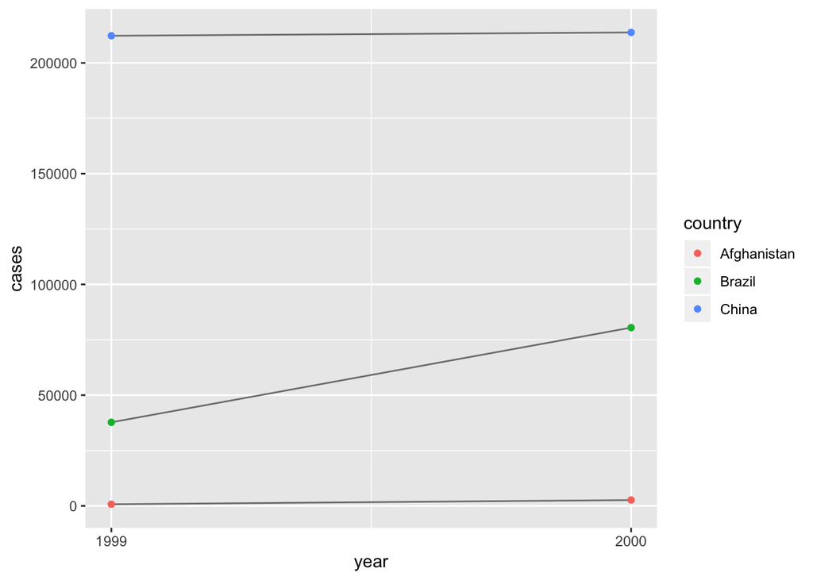

```r
table2 %>% filter(type=="cases") %>%
    ggplot(aes(year, count)) +
    geom_line(aes(group=country), colour="grey50") +
    geom_point(aes(colour=country)) +
    scale_x_continuous(breaks=unique(table2$year)) +
    ylab("cases")
```

# 11.3.5

## 1

> What are the most important arguments to `locale()`?

```r
?locale()
```

`locale()` determine that - data format - time zone - numbers - encoding

## 2

> What happens if you try and set `decimal_mark` and `grouping_mark` to the same character? What happens to the default value of `grouping_mark` when you set `decimal_mark` to `","`? What happens to the default value of `decimal_mark` when you set the `grouping_mark` to `"."`?

```
locale(decimal_mark = ".", grouping_mark = ".")
```

```r
locale(decimal_mark = ",")
```

```
## <locale>
## Numbers:  123.456,78
## Formats:  %AD / %AT
## Timezone: UTC
## Encoding: UTF-8
## <date_names>
## Days:   Sunday (Sun), Monday (Mon), Tuesday (Tue), Wednesday (Wed),
##         Thursday (Thu), Friday (Fri), Saturday (Sat)
## Months: January (Jan), February (Feb), March (Mar), April (Apr), May
##         (May), June (Jun), July (Jul), August (Aug), September
##         (Sep), October (Oct), November (Nov), December (Dec)
## AM/PM:  AM/PM
```

```r
locale(grouping_mark = ",")
```

```
## <locale>
## Numbers:  123,456.78
## Formats:  %AD / %AT
## Timezone: UTC
## Encoding: UTF-8
## <date_names>
## Days:   Sunday (Sun), Monday (Mon), Tuesday (Tue), Wednesday (Wed),
##         Thursday (Thu), Friday (Fri), Saturday (Sat)
## Months: January (Jan), February (Feb), March (Mar), April (Apr), May
##         (May), June (Jun), July (Jul), August (Aug), September
##         (Sep), October (Oct), November (Nov), December (Dec)
## AM/PM:  AM/PM
```

## 3

> I didn’t discuss the `date_format` and `time_format` options to `locale()`. What do they do? Construct an example that shows when they might be useful.

```r
parse_date("19 junio 2019", "%d %B %Y", locale=locale("es"))
```

```
## [1] "2019-06-19"
```

## 4

> If you live outside the US, create a new locale object that encapsulates the settings for the types of file you read most commonly.

```r
japan_locale <- locale(date_format="%Y年%m月%d日")
parse_date("2019年6月19日", locale = japan_locale)
```

```
## [1] "2019-06-19"
```

## 5

> What’s the difference between `read_csv()` and `read_csv2()`?

Difference is delimiter.

## 6

> What are the most common encodings used in Europe? What are the most common encodings used in Asia? Do some googling to find out.

skip

## 7

> Generate the correct format string to parse each of the following dates and times:

```r
d1 <- "January 1, 2010"
d2 <- "2015-Mar-07"
d3 <- "06-Jun-2017"
d4 <- c("August 19 (2015)", "July 1 (2015)")
d5 <- "12/30/14" # Dec 30, 2014
t1 <- "1705"
t2 <- "11:15:10.12 PM"
```

Following format is correct;

```r
parse_date(d1, "%B %d, %Y")
```

```
## [1] "2010-01-01"
```

```r
parse_date(d2, "%Y-%b-%d")
```

```
## [1] "2015-03-07"
```

```r
parse_date(d3, "%d-%b-%Y")
```

```
## [1] "2017-06-06"
```

```r
parse_date(d4, "%B %d (%Y)")
```

```
## [1] "2015-08-19" "2015-07-01"
```

```r
parse_date(d5, "%m/%d/%y")
```

```
## [1] "2014-12-30"
```

```r
parse_time(t1, "%H%M")
```

```
## 17:05:00
```